# Modelos espaciales para la NBA

Derek Corcoran  
"2017-04-03"

### La revolucion estadística en la NBA

**Philadelphia 76ers:**

- Dr. Lance Pearson (Coordinator of Coaching Analytics)
- Sergi Oliva (Director of Basketball Analytics & Innovation)
- Alex Rucker (Vice President - Analytics and Strategy)
- Andy Miller (Senior Researcher)
- Alex D’Amour (Senior Researcher)
- Alex Franks (Senior Researcher)
- Grant Fiddyment (Data Scientist)
- Michael Lai (Data Scientist) .

[figure not shown]

2004

[figure not shown]

- Congreso anual en MIT en Boston
- 11 años
- 4.000 participantes o
- 1.500 estudiantes de 320 instituciones academicas
- 130 equipos profesionales

[figure not shown]

### Que es SportsVU

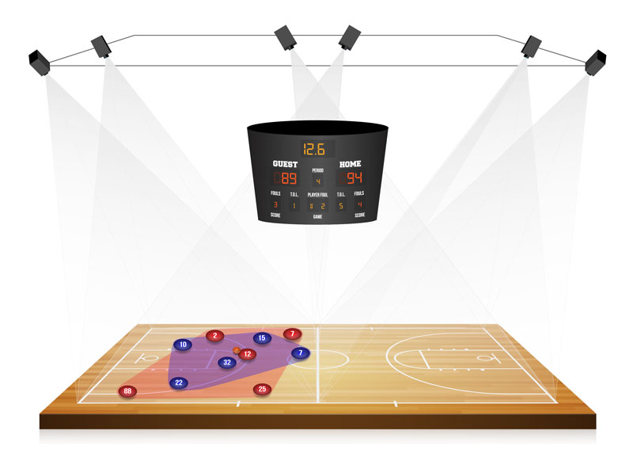

- Seguimiento de jugadores en tiempo real con 6 camaras
- Información registrada 25 veces por segundo
- Algunas de los valores registrados
  - Posición
  - Velocidad
  - Distancia a otros jugadores
  - Pases
  - Tipos de tiro .

### Esto permite seguimientos como este

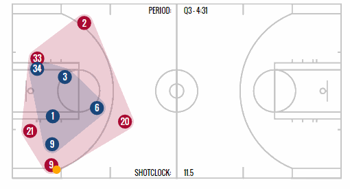

### y generar datos como este:

| PLAYER_NAME | SHOT_TYPE | SHOT_DISTANCE | LOC_X | LOC_Y | SHOT_MADE_FLAG | HTM | VTM |
| --- | --- | --- | --- | --- | --- | --- | --- |
| Andre Drummond | 2PT Field Goal | 1 | -17 | -6 | 0 | ATL | DET |
| Marcus Morris | 2PT Field Goal | 13 | 117 | 67 | 1 | ATL | DET |
| Paul Millsap | 2PT Field Goal | 12 | 76 | 95 | 1 | ATL | DET |
| Kentavious Caldwell-Pope | 2PT Field Goal | 8 | -68 | 51 | 1 | ATL | DET |
| Al Horford | 2PT Field Goal | 20 | -117 | 164 | 0 | ATL | DET |
| Andre Drummond | 2PT Field Goal | 8 | -79 | 31 | 0 | ATL | DET |
| Paul Millsap | 2PT Field Goal | 12 | 123 | 3 | 1 | ATL | DET |

.

### Todos los tiros del 2017

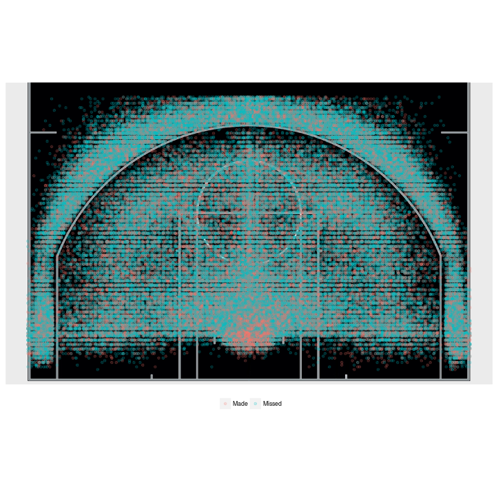

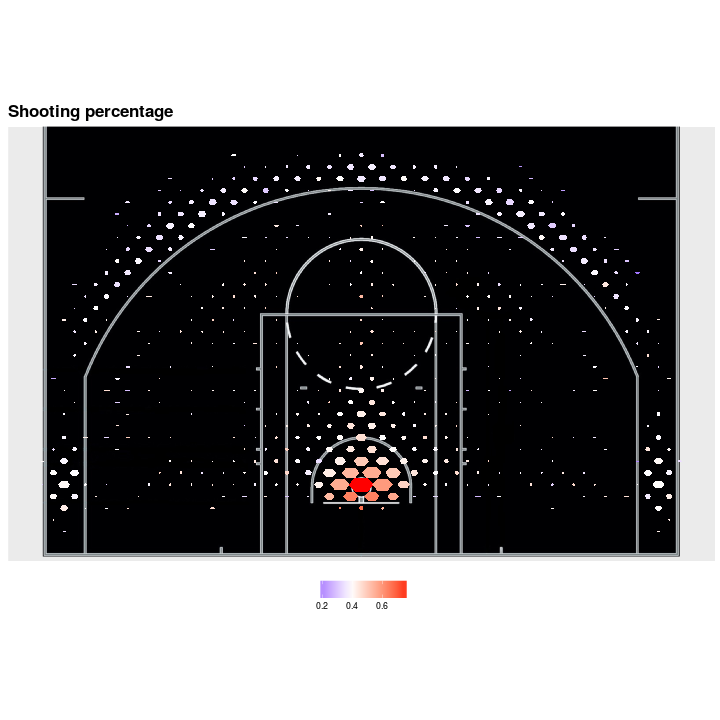

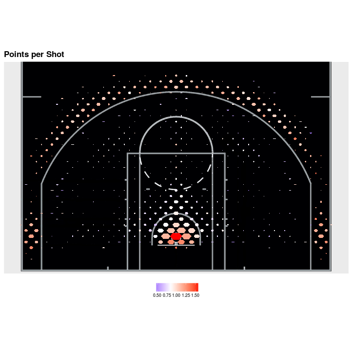

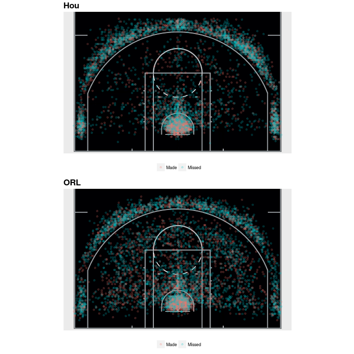

### A tale of 2 Shot Charts

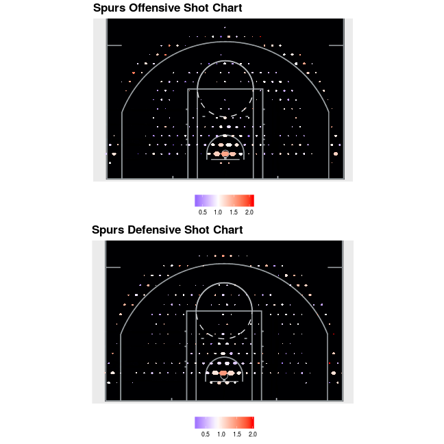

### A tale of 2 Shot Charts

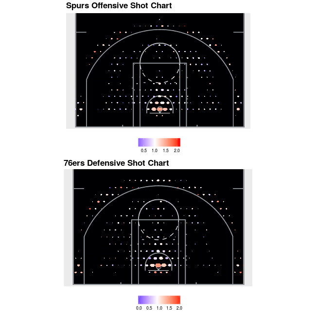

### ecuaciones

\( PPS = \frac{Points Made}{Shots Taken} \)

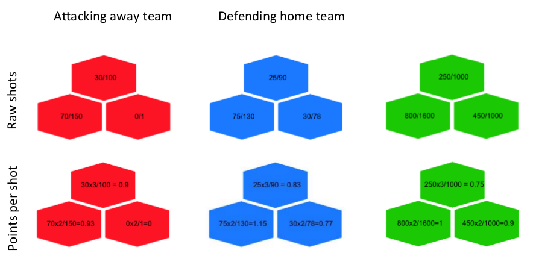

\( POA_{i} = PPS_{Team_{i}}-PPS_{League_{i}} \) \( APPS =\frac{\sum_{i=1}^{n} (POA_{Offense_i} + POA_{Defense_i})\times ShotsTaken_{Offense_i}}{n\times ShotsTaken_{Offense_Total}} \)

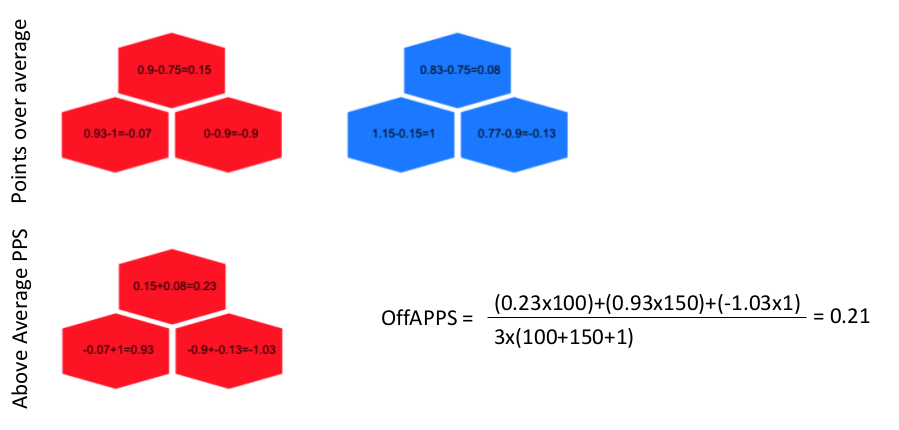

Invirtiendo con el equipo de casa atacando tenemos DefAPPS .

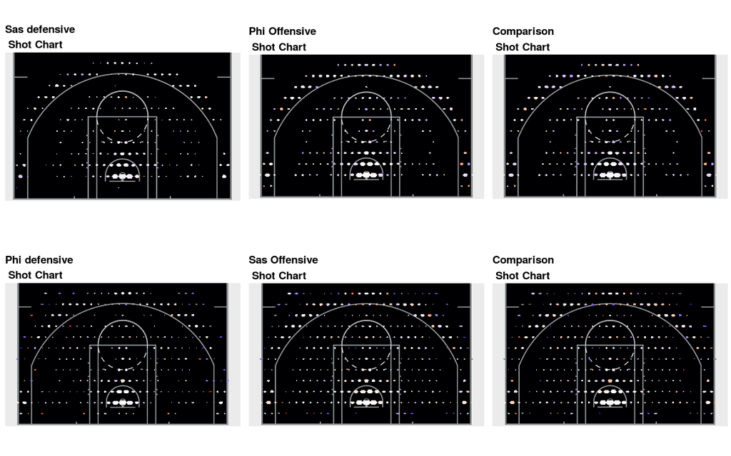

### Datos colectados

- Usamos partidos de temporada regular desde el 2013 hasta el 2017
- Partidos de playoff de 2012 a 2016
- Total de partidos 6,601
- Debido a alta variabilidad en el inicio de la temprorada n final = 4,023
- Total de tiros de análisis 1,174,831
- DefAPPS y OffAPPS calculados para cada partido .

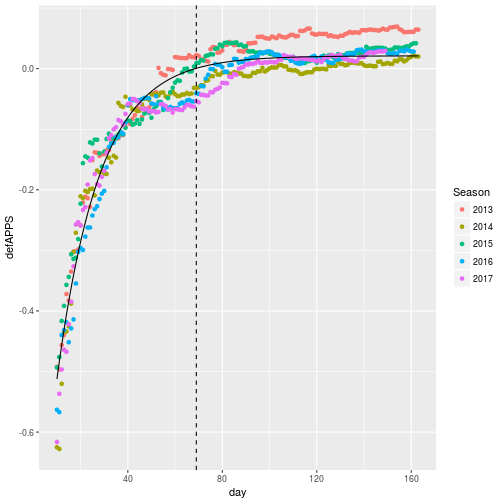

### Spread

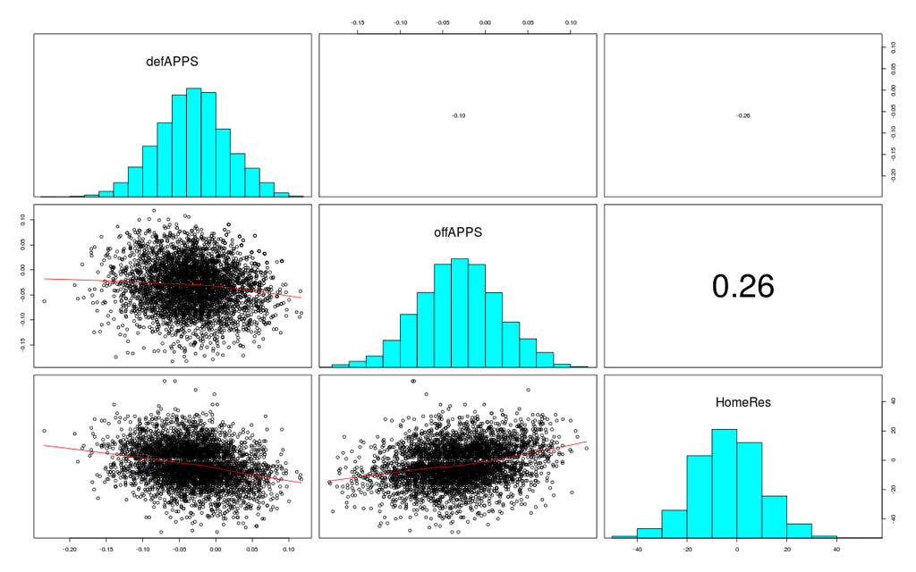

### Boosted Regression Trees

- Algoritmo de Machine Learning
- Spread ~ OffAPPS + DefAPPS
- Training set de 3,337partidos
- Test set 686 partidos

[figure not shown]

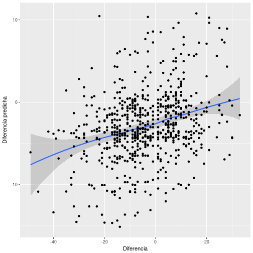

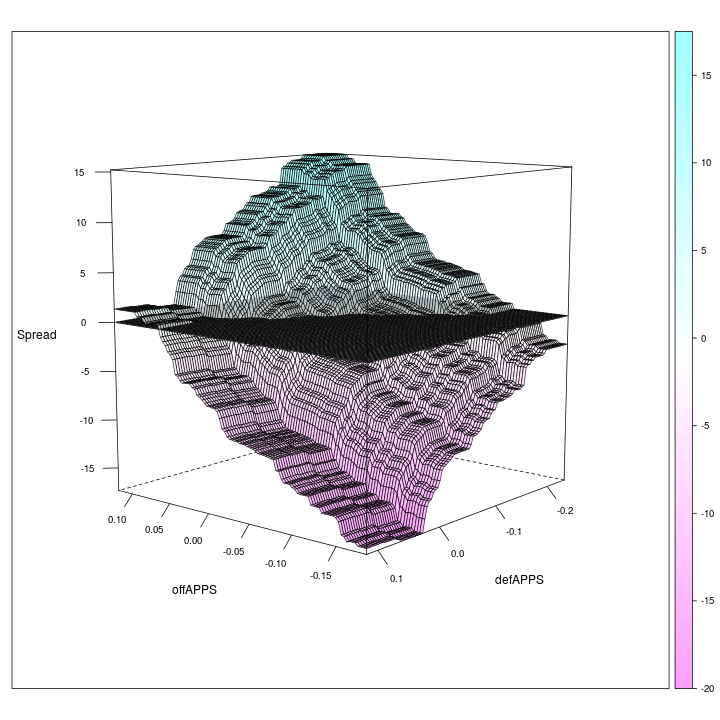